# Breast Cancer Coimbra Classification

Maria Margherita Lovera

12/05/2020

# Introduction and dataset description

The aim of this paper is to analyse a dataset and to apply Machine Learning algorithms to produce a reliable result. The object of this study is the dataset **Breast Cancer Coimbra** taken from [UCI Machine Repository](http://archive.ics.uci.edu/ml/datasets/Breast+Cancer+Coimbra) containing clinical features of 116 patiens. Clinical features were observed for 64 patients with breast cancer and the reamining 52 who regularly attend healthy controls. Every patient is identified by a list of attirbutes. All the attributes except from the last one are predictors, while the final attribute is the target attribute. We list them below:

- Age: patient age;
- BMI: body mass index (kg/m2);
- Glucose (mg/dL);
- Insulin (U/mL);
- HOMA: Homeostasis Model Assessment;
- Leptin (ng/mL);
- Adiponectin (µg/mL);
- Resistin (ng/mL);
- MCP-1: Monocyte Chemoattractant Protein-1 (pg/dL);
- Classification: 1 = healthy controls, 2 = breast cancer

The 9 predictors are quantitative, while the response is a binary dependent variable, indicating the precence or absence of breast cancer. The predictors are anthropometric data and parameters which can be gathered in routine blood analysis. Prediction models based on these predictors, if accurate, can potentially be used as a biomarker of breast cancer. The paper’s goal is to produce different models that are able to classify as accurately as possible a patient’s health, given her clinical features.

# Variables analysis

First of all, we load the packages we need for the analysis and the given dataset.

```r
#clean space
rm(list=ls())

#libraries
suppressMessages(library(ggplot2))
suppressMessages(library(corrplot))
suppressMessages(library(ggpubr))
suppressMessages(library(MASS))
suppressMessages(library(MVN))
suppressMessages(library(caret))
suppressMessages(library(class))
suppressMessages(library(boot))
suppressMessages(library(rpart.plot))
suppressMessages(library(rpart))
suppressMessages(library(randomForest))
suppressMessages(library(e1071))
suppressMessages(library(pROC))


#set working directory
setwd("~/Desktop/Tesina")

#load data
cancer<-read.csv("dataR2.csv")

#dataset dimension and structure
dim(cancer)
```

```
## [1] 116  10
```

```r
head(cancer)
```

|  | Age | BMI | Glucose | Insulin | HOMA | Leptin | Adiponectin | Resistin | MCP.1 | Classification |
| --- | --- | --- | --- | --- | --- | --- | --- | --- | --- | --- |
| 1 | 48 | 23.50000 | 70 | 2.707 | 0.4674087 | 8.8071 | 9.702400 | 7.99585 | 417.114 | 1 |
| 2 | 83 | 20.69049 | 92 | 3.115 | 0.7068973 | 8.8438 | 5.429285 | 4.06405 | 468.786 | 1 |
| 3 | 82 | 23.12467 | 91 | 4.498 | 1.0096511 | 17.9393 | 22.432040 | 9.27715 | 554.697 | 1 |
| 4 | 68 | 21.36752 | 77 | 3.226 | 0.6127249 | 9.8827 | 7.169560 | 12.76600 | 928.220 | 1 |
| 5 | 86 | 21.11111 | 92 | 3.549 | 0.8053864 | 6.6994 | 4.819240 | 10.57635 | 773.920 | 1 |
| 6 | 49 | 22.85446 | 92 | 3.226 | 0.7320869 | 6.8317 | 13.679750 | 10.31760 | 530.410 | 1 |

```r
str(cancer)
```

```
## 'data.frame':    116 obs. of  10 variables:
##  $ Age           : int  48 83 82 68 86 49 89 76 73 75 ...
##  $ BMI           : num  23.5 20.7 23.1 21.4 21.1 ...
##  $ Glucose       : int  70 92 91 77 92 92 77 118 97 83 ...
##  $ Insulin       : num  2.71 3.12 4.5 3.23 3.55 ...
##  $ HOMA          : num  0.467 0.707 1.01 0.613 0.805 ...
##  $ Leptin        : num  8.81 8.84 17.94 9.88 6.7 ...
##  $ Adiponectin   : num  9.7 5.43 22.43 7.17 4.82 ...
##  $ Resistin      : num  8 4.06 9.28 12.77 10.58 ...
##  $ MCP.1         : num  417 469 555 928 774 ...
##  $ Classification: int  1 1 1 1 1 1 1 1 1 1 ...
```

Before starting our analysis, we need to check if there are missing values and convert the target attribute *Classification* into a factor: as stated before, we set the label ‘*healthy controls*’ for healthy patients and ‘*breast cancer*’ for patients with breast cancer.

```r
#missing values
table(is.na(cancer))
```

```
##
## FALSE
##  1160
```

```r
#we transform the target attribute into a factor
cancer$Classification<-factor(cancer$Classification, levels = c(1,2),
                              labels = c("healthy controls","breast cancer"))

#let's check again our dataset
summary(cancer)
```

```
##       Age            BMI           Glucose          Insulin
##  Min.   :24.0   Min.   :18.37   Min.   : 60.00   Min.   : 2.432
##  1st Qu.:45.0   1st Qu.:22.97   1st Qu.: 85.75   1st Qu.: 4.359
##  Median :56.0   Median :27.66   Median : 92.00   Median : 5.925
##  Mean   :57.3   Mean   :27.58   Mean   : 97.79   Mean   :10.012
##  3rd Qu.:71.0   3rd Qu.:31.24   3rd Qu.:102.00   3rd Qu.:11.189
##  Max.   :89.0   Max.   :38.58   Max.   :201.00   Max.   :58.460
##       HOMA             Leptin        Adiponectin        Resistin
##  Min.   : 0.4674   Min.   : 4.311   Min.   : 1.656   Min.   : 3.210
##  1st Qu.: 0.9180   1st Qu.:12.314   1st Qu.: 5.474   1st Qu.: 6.882
##  Median : 1.3809   Median :20.271   Median : 8.353   Median :10.828
##  Mean   : 2.6950   Mean   :26.615   Mean   :10.181   Mean   :14.726
##  3rd Qu.: 2.8578   3rd Qu.:37.378   3rd Qu.:11.816   3rd Qu.:17.755
##  Max.   :25.0503   Max.   :90.280   Max.   :38.040   Max.   :82.100
##      MCP.1                  Classification
##  Min.   :  45.84   healthy controls:52
##  1st Qu.: 269.98   breast cancer   :64
##  Median : 471.32
##  Mean   : 534.65
##  3rd Qu.: 700.09
##  Max.   :1698.44
```

There aren’t missing values in our dataset. By looking at the summary, we observe some statistics about the attributes. For every numerical attribute the summary shows the mean, the minimum, the maximum, the median and the quartiles. From these informations we have the confirmation that we can start our analysis without any further work on the dataset since transformations or cleansing of the data are not needed. The target attribute shows that the dataset is quite balanced between the two classes.

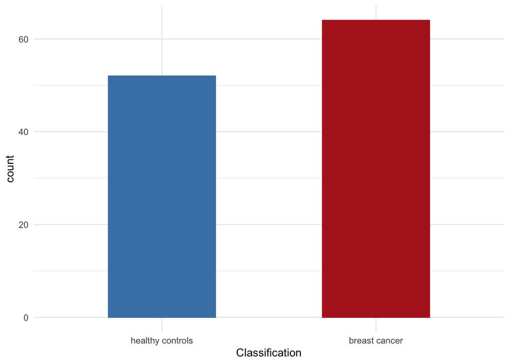

```r
ggplot(data = cancer, aes(x = Classification,)) +
  geom_bar(fill=c("steelblue","firebrick"), color=c("steelblue","firebrick"), width=0.5) + theme_minimal()
```

In particular there are 52 women (44.8%) who attend healthy controls and 64 women (55.2%) who have breast cancer. Now we want to know if there are some correlations between predictors: in order to do this, we observe the following plot that represents the correlation matrix of the dataset.

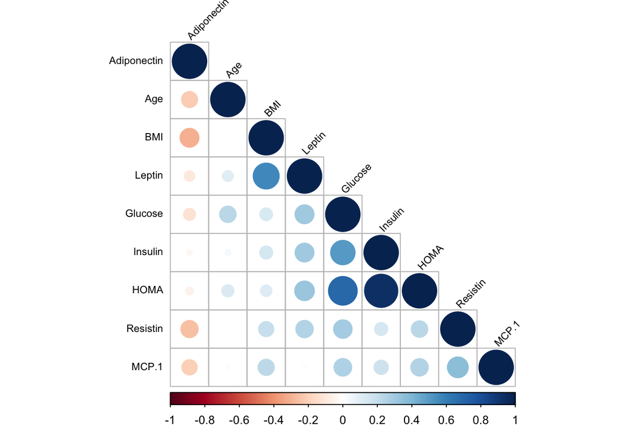

```r
corrplot(cor(cancer[,-10]), type = "lower", tl.cex=.7, order = "hclust", tl.col = "black", tl.srt = 45)
```

In the graph above the darkness of the color is proportional to the diameter of the circle: blue circles mean that the two attirbutes are positively correlated, red circles represent couples of negatively correlated features, and very light or white circles characterize pairs of practically non-correlated attributes. This graphic was made ordering the features for hierarchical clustering: in this way we can find features that are strongly correlated next to each other. It is clear from the correlation matrix represented in the plot that there is a strong positive correlation between *Insulin* and *HOMA*. This is reasonable, since *HOMA* is an index that evaluate the insulin resistance of the subject: low HOMA means that the subject is sensitive to insulin. In order to underline the correlation between the mentioned features we look at some pairplots, where we also considered *Glucose* since it seems to have a quite strong positive correlation with *HOMA* too:

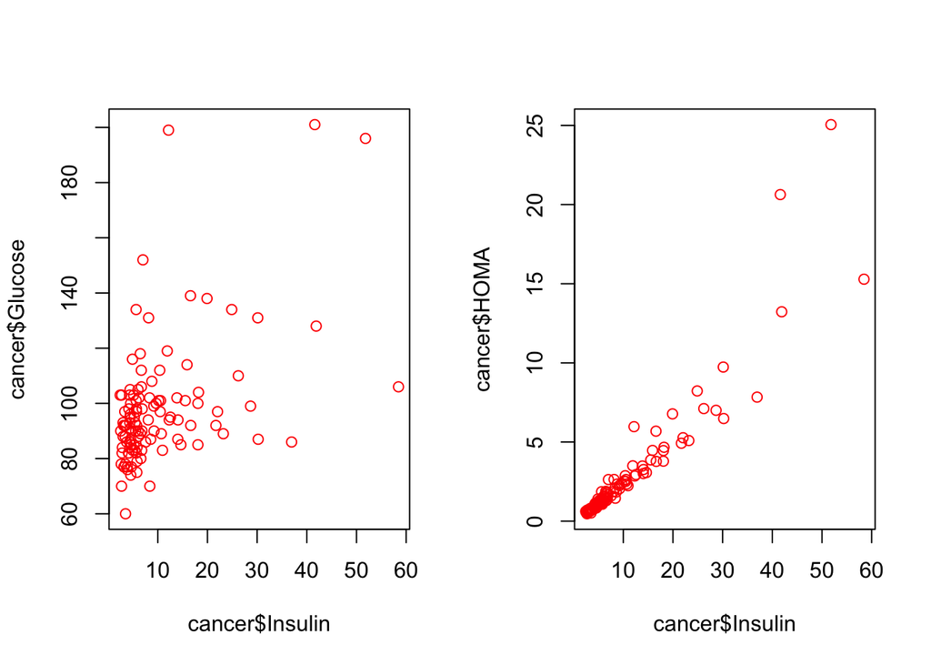

```r
par(mfrow=c(1,2))
plot(cancer$Insulin,cancer$Glucose, type = "p", col="red")
plot(cancer$Insulin,cancer$HOMA, type = "p", col="red")
```

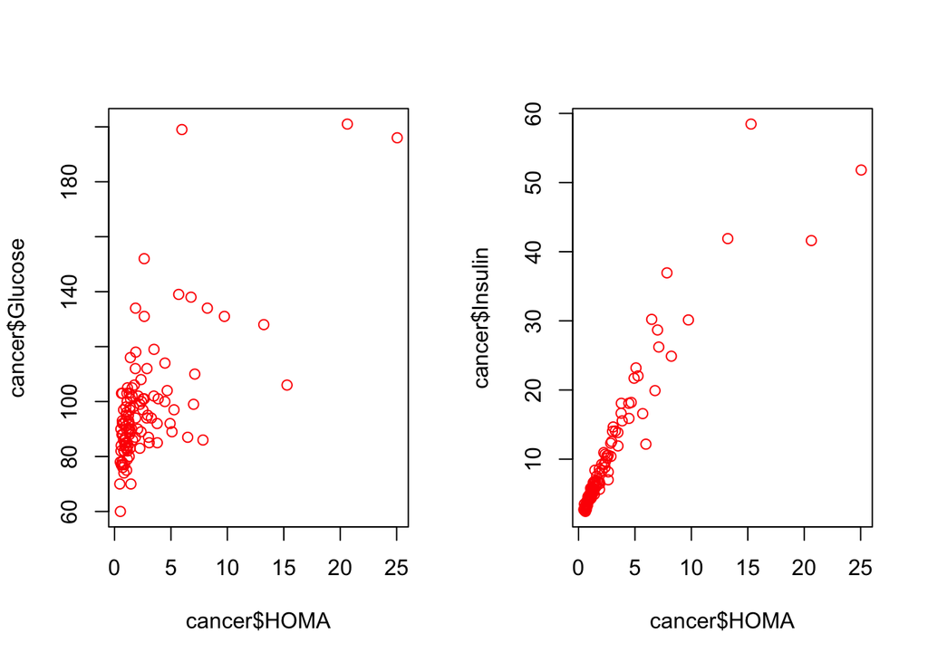

```r
par(mfrow=c(1,2))
plot(cancer$HOMA,cancer$Glucose, type = "p", col="red")
plot(cancer$HOMA,cancer$Insulin, type = "p", col="red")
```

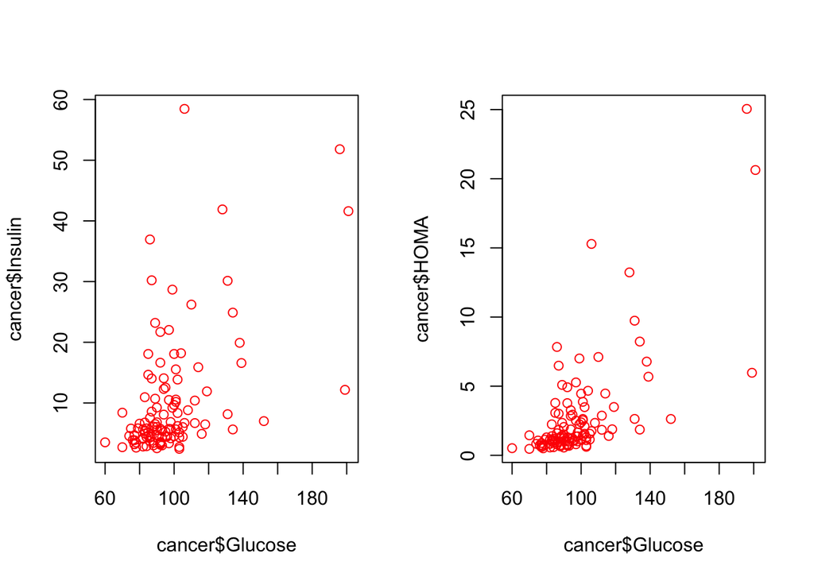

```r
par(mfrow=c(1,2))
plot(cancer$Glucose,cancer$Insulin, type = "p", col="red")
plot(cancer$Glucose,cancer$HOMA, type = "p", col="red")
```

Let’s also check the correlation coefficients:

```r
cor(cancer$Glucose,cancer$Insulin)
```

```
## [1] 0.5046531
```

```r
cor(cancer$Glucose,cancer$HOMA)
```

```
## [1] 0.6962118
```

```r
cor(cancer$Insulin,cancer$HOMA)
```

```
## [1] 0.9321978
```

The graphics and the correlation coefficients show quite clearly what was shown in the correlation plot: *HOMA* grow almost linearly with Insulin. This is reasonable since low HOMA represents more sensitivity to insulin. Also *Glucose* is quite correlated with both *Insulin* and *HOMA*, but on a lower level. Given these informations about the correlation between features, we decided to perform our analysis on the dataset without considering the attribute *HOMA*, aiming to an easier study and interpretation of the results.

# Classification

In building our classifiers we split the dataset we want to study into two sets. The first one, called training set, contains 81 observations corresponding to the 70% of the whole dataset and it is used to build the different classifiers. The second one, called test or validation set, contains the remaining 35 points of the dataset and it is used to see how the classifiers perform in terms of accuracy on some observations that were not used to build the models. As stated before we will work with 8 predictors instead of 9 since we decided to remove the attribute *HOMA*.

```r
names(cancer) <- make.names(names(cancer))

set.seed(2000)
Samples = sample(1:nrow(cancer),nrow(cancer)*0.7)
TrainSet = cancer[Samples,-5]
TestSet = cancer[-Samples,-5]
table(TrainSet$Classification)
```

```
##
## healthy controls    breast cancer
##               38               43
```

```r
table(TestSet$Classification)
```

```
##
## healthy controls    breast cancer
##               14               21
```

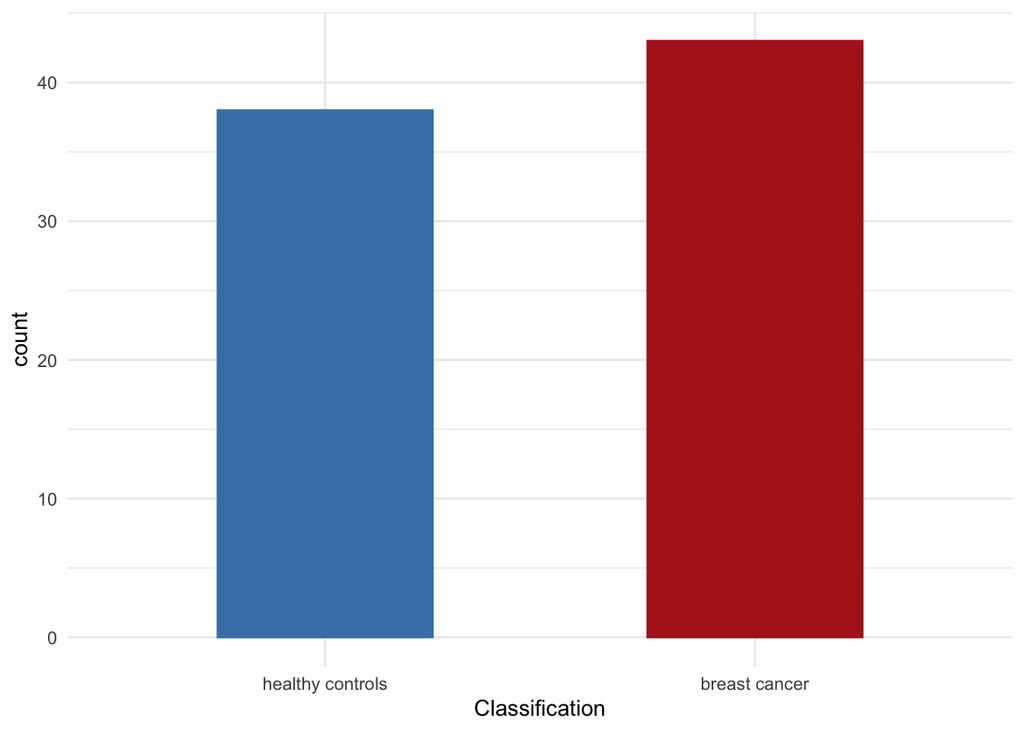

```r
par(mfrow=c(1,1))
ggplot(data = TrainSet, aes(x = Classification,)) +
  geom_bar(fill=c("steelblue","firebrick"), color=c("steelblue","firebrick"), width=0.5) + theme_minimal()
```

From the tables and graphs above we notice that observations inside the training set seem to be balanced between the two classes as our original dataset. This makes us believe that we will be able to perform our analysis without too many difficulties.

## Logistic regression with Leave-One-Out Cross-Validation

The first technique we use to try to classify our points is called *Logistic Regression*. This method is applied to classification problems and it aims to predict the probability that an instance belongs to a particular class, given the values of the predictors. In our classification problem we have a binary response variable representing the patient’s health condition that can assume ‘*healthy controls*’ and ‘*breast cancer*’ as values. We want to predict the probability that a patient has breast cancer, i.e. that the dependent variable is equal to ‘*breast cancer*’: in order to keep this probability in the interval $[0,1]$ we need *Logistic Regression*. This name comes from the fact that the link function of this regression model is the so-called logit function, defined as $logit(x)=log(\frac{x}{1-x})$. This function forces the probability that the response variable is equal to ‘*breast cancer*’ to belong to $[0,1]$. If we define $\pi=\mathbb{P}(Y='breast \quad cancer'| X)$, where $Y$ represents the *Classification* attribute and $X$ represents the array composed by the predictors, then the logistic model can be written as

$logit(\pi)=log(\frac{\pi}{1-\pi})=\beta_0+\sum_{i=1}^{8}{\beta_iX_i}$

$\pi=\frac{exp(\beta_0+\sum_{i=1}^{8}{\beta_iX_i})}{1+exp(\beta_0+\sum_{i=1}^{8}{\beta_iX_i})}$

where 8 is the number of predictors of our model. In this way we are able to model the conditional distribution of the response variable $Y$ given the array of 8 predictors $X$.

In order to select the best possible generalized linear model we use *cross-validation*: in particular here we fit the model with the technique of *leave-one-out cross-validation*. There are different methods to perform *cross-validation*: one method consists in dividing the set that we use to build the model into $K$ subsets of the same cardinality called folds. At the beginning the first fold is the testing set and the other $K-1$ folds consitute the training set; then this process is repeated $K$ times considering at each time a different fold as the testing set. In this way we get $K$ estimates of the test error and at the end we take the model with the highest accuracy as the final classifier. Some of the most common stategies are given by dividing the training set in 5 folds, 10 folds or $n$ folds, where $n$ is the number of observations of the dataset. Here we perform the last one, called *leave-one-out cross-validation* since a single observation is used for the testing set while the remaining obervations make up the training set. Notice that in our case it is possible to perform LOOCV without having computational problems because we don’t have a lot of observations, but in general it’s easy to understand that performing 5-fold or 10-fold cross-validation is much more feasible.

```r
set.seed(2005)

LOOfit<-train(Classification~.,
               data = TrainSet,
               trControl = trainControl(method = 'LOOCV'),
               method = 'glm',
               family = 'binomial'
               )
```

The result of this analysis produces the following model:

```r
LOOModel<-LOOfit$finalModel
summary(LOOModel)
```

```
##
## Call:
## NULL
##
## Deviance Residuals:
##      Min        1Q    Median        3Q       Max
## -2.18935  -0.72283   0.04764   0.59873   2.36950
##
## Coefficients:
##              Estimate Std. Error z value Pr(>|z|)
## (Intercept) -2.202651   3.139460  -0.702 0.482928
## Age         -0.043328   0.020750  -2.088 0.036784 *
## BMI         -0.213371   0.081973  -2.603 0.009242 **
## Glucose      0.109178   0.030287   3.605 0.000312 ***
## Insulin      0.072693   0.052363   1.388 0.165057
## Leptin      -0.018286   0.021700  -0.843 0.399415
## Adiponectin -0.076635   0.053552  -1.431 0.152415
## Resistin     0.047864   0.026817   1.785 0.074289 .
## MCP.1        0.000745   0.001025   0.727 0.467217
## ---
## Signif. codes:  0 '***' 0.001 '**' 0.01 '*' 0.05 '.' 0.1 ' ' 1
##
## (Dispersion parameter for binomial family taken to be 1)
##
##     Null deviance: 111.981  on 80  degrees of freedom
## Residual deviance:  72.532  on 72  degrees of freedom
## AIC: 90.532
##
## Number of Fisher Scoring iterations: 6
```

As we can see in the summary, not all the predictors included in the model have a very significant impact in predicting the class of an observation. In particular, just *Glucose*, *BMI* and *Age* seem to be quite significant for an observation in the prediction of its class. Now we want to see how our model perform on the validation set: the patients whose probability to have breast cancer greater than 0.5 are classified into the ‘*breast cancer*’ class while those with probability less than or equal to 0.5 are classified into the ‘*healthy controls*’ group.

```r
LOOprob <- predict(LOOModel, TestSet, type="response")
LOOpred <- factor(LOOprob > .5, levels=c(FALSE, TRUE),labels=c("healthy controls", "breast cancer"))
```

Now we print a confusion matrix, i.e. a tabular view of the good and bad predictions in order to determine the accuracy of the model we built.

```r
LOOtable<-table(LOOpred, TestSet$Classification, dnn=c("Predicted", "Actual"))
LOOtable
```

```
##                   Actual
## Predicted          healthy controls breast cancer
##   healthy controls               11             6
##   breast cancer                   3            15
```

```r
accLOO<-sum(diag(LOOtable))/sum(LOOtable)
accLOO
```

```
## [1] 0.7428571
```

## LDA

*Linear Discriminant Analysis* is a supervised learning algorithm that helps to find a linear combination of features that separates the two classes of our dataset. The idea of this technique is to find a direction $v$ and project each sample of the dataset onto the line defined by $v$ in order to separate as much as possible the two classes of points. This direction $v$ is called linear discriminant.

In order to be able to classify optimally our points we need to know the posterior distributions, i.e. $\mathbb{P}(Y=k|X)$, where $Y=k$ means that the response variable $Y$ belongs to the class $k$. If we call $\pi_k$ the prior probability of belonging to class $k$ and $f_k(x)$ is the class-conditional density of $X$ in class $Y=k$, then for Bayes theorem we have

$\mathbb{P}(Y=k|X=x)=\frac{f_k(x)\pi_k}{\sum_{j=1}^{K}{f_j(x)\pi_j}} \quad \forall k=1,\dots,K$

where $K$ is the number of classes of the dataset. By hypotesis, each of the classes density must have a Gaussian multivariate distribution

$f_k(x)=\frac {1}{(2\pi)^{p/2}|\Sigma_k|^{1/2}} \exp(-\frac{1}{2}(x-\mu_k)^T\Sigma_k^{-1}(x-\mu_k)), \quad \forall k=1,\dots,K$

where $\mu_k$ and $\Sigma_k$ are the mean and covariance matrix of class $k$ points and $p$ is the number of predictors. Moreover all classes must have the same covariance matrix $\Sigma_K=\Sigma$. Now we can state that the decision rule: a point is assigned to the class for which the linear discriminant functions

$\delta_k(x)=x^T\Sigma^{-1}\mu_k-\frac {1}{2}\mu_k^T\Sigma^{-1}\mu_k+\log \pi_k$

is largest. We give to the set where $\delta_k(x)=\delta_l(x)$ with $k$ and $l$ two different classes, the name of decision boundary between the two classes: then, according to the previous equation, this set is linear in $x$ so it is an hyperplane and it separates the whole space $\mathbb{R}^p$ into two regions, each of whom contains the points from a single class.

So let’s check if the two assumptions stated above are met in our dataset:

```r
#first assumption: the two groups have the same covariance matrix
group1<- cancer[cancer$Classification=="healthy controls",c(-5,-10)]
group2<- cancer[cancer$Classification=="breast cancer",c(-5,-10)]
sigma1=cov(group1)
sigma2=cov(group2)
norm(sigma1-sigma2, type = "I")
```

```
## [1] 69793.15
```

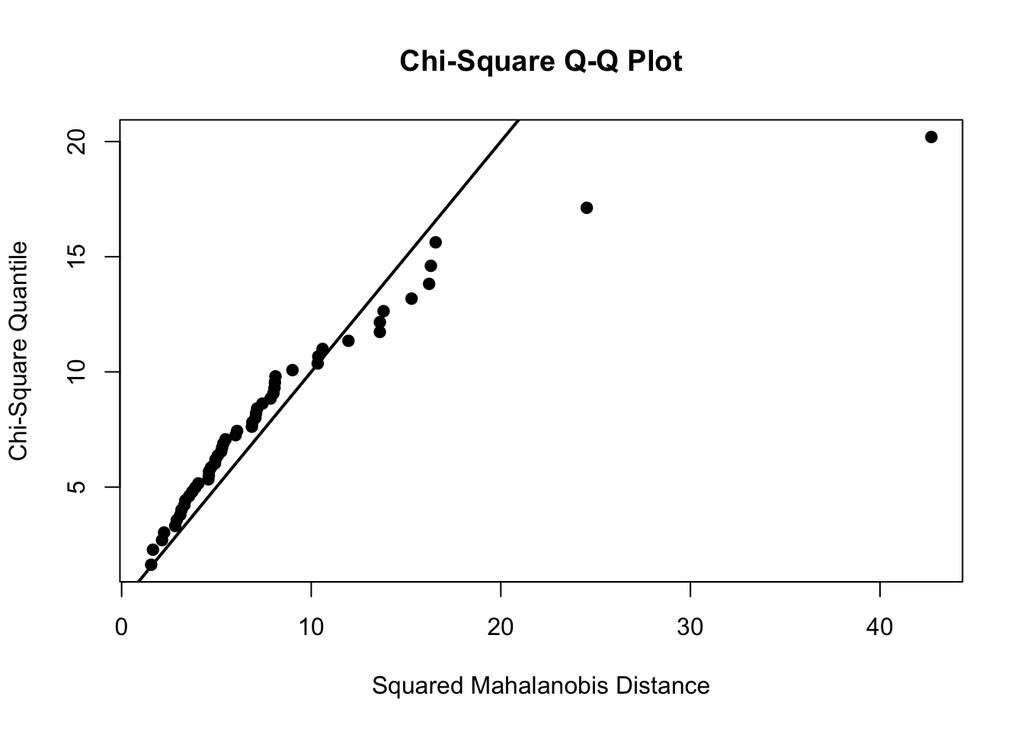

```r
#second assumption:density of both classes given by a Gaussian multivariate distribution
plot1<-mvn(data = group1, multivariatePlot = "qq")
```

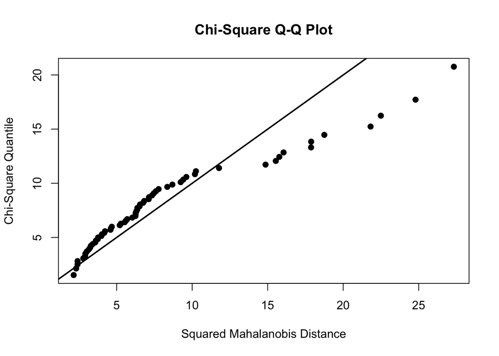

```r
plot2<-mvn(data = group2, multivariatePlot = "qq")
```

As we can see from the results obtained, both the assumption are not met. So it is not reasonable to perform *LDA* because the results obtained would not be reliable.

## $k$-Nearest Neighbors with Leave-One-Out Cross-Validation

The algorithm of *$k$-nearest neighbors ($k$NN)* assumes that observations which are similar are also near to each other. Obviuosly this idea requires a criterion to measure the similarity of two instances of the dataset: this is usually given by the Euclidean distance between points. In order to give to all the features the same weight the dataset needs to be normalized before measuring the distances between different obseravtions. The *$k$NN* method needs a set of observations for which the class is known, again called training set, and an integer $k$ to be decided before performing the algorithm. For every new point that we want to classify given the vector of features, the algorithm computes the distance between this point and every point of the training set and then it selects the $k$ points with the smaller distance to it. The new observation is assigned to the class which is more represented among the $k$ selected points. This algorithm is very useful for datasets that are not too big both in terms of features and instances. The key decision that has to be made before fitting this model is the value of $k$: since we have a binary classification problem, we take an odd number for $k$ in order to avoid cases where a point has the same number of class-1 and class-2 neighbors. A small value of $k$ generates an unstable prediction model, while a large value makes the model computationally heavy. The best way to create an accurate model is to use cross validation to select the proper value of $k$: this means that we try different values for $k$ and then chosing the value that maximizes the accuracy of the model.

Also in this case we fit the model by performing the *Leave-One-Out cross-validation*. In order to understand which is the best value of $k$ in the *$k$NN model* we use the *Leave-One-Out cross-validation* for all the odd values of $k$ between 3 and 15.

```r
set.seed(2058)
kNNModel <- train(TrainSet[,-9], TrainSet[,9],
                  method = "knn",
                  preProcess = c("center", "scale"),
                  tuneGrid = expand.grid(k = seq(3,15,2)),
                  trControl = trainControl(method = "LOOCV"),
                  metric = "Accuracy"
)
kNNModel
```

```
## k-Nearest Neighbors
##
## 81 samples
##  8 predictor
##  2 classes: 'healthy controls', 'breast cancer'
##
## Pre-processing: centered (8), scaled (8)
## Resampling: Leave-One-Out Cross-Validation
## Summary of sample sizes: 80, 80, 80, 80, 80, 80, ...
## Resampling results across tuning parameters:
##
##   k   Accuracy   Kappa
##    3  0.6666667  0.3318057
##    5  0.7037037  0.4033149
##    7  0.6913580  0.3813016
##    9  0.6790123  0.3555692
##   11  0.6666667  0.3297579
##   13  0.6790123  0.3575351
##   15  0.6790123  0.3575351
##
## Accuracy was used to select the optimal model using the largest value.
## The final value used for the model was k = 5.
```

```r
#save the best value for k
kappa <- kNNModel$bestTune$k
```

So the value of $k$ that maximizes the accuracy in the *Leave-One-Out cross-validation* performed is $k=5$, so we select it to perform a *$k$NN* model and see how it works on the validation set.

```r
kNNpred<- knn(train = TrainSet[,-9], test = TestSet[,-9], cl=TrainSet[,9], k=kappa)
kNN_table<-table(kNNpred, TestSet[,9], dnn=c("Predicted", "Actual"))
kNN_table
```

```
##                   Actual
## Predicted          healthy controls breast cancer
##   healthy controls                6             7
##   breast cancer                   8            14
```

```r
kNNaccuracy<-sum(diag(kNN_table))/sum(kNN_table)
kNNaccuracy
```

```
## [1] 0.5714286
```

The accuracy of this classifier is about 57% which is rather lower than what we got with logistic regression. This is clear from the table above: just 14 out of 21 patients with breast cancer are correclty classified and just 6 out of 14 healthy patients result having healthy controls. This may be due to the fact that we use 8 predictors and in a quite high-dimensional space the distances between points are not so different. In order to see what happens to the model in a lower-dimensional space we decided to perform a feature extraction with the aim of reducing the dimensionality of our dataset.

### PCA

*Principal component analysis* is an unsupervised learning technique that is used to find the directions along which the data have the maximum variance: these directions are normalized linear combinations of the variables with highest variance. Once the features related to these directions are found, the others can be ignored while losing small information about the dataset, as the data have small variance along the ignored directions. The orthogonal axes (principal components) of the new subspace can be interpreted as the directions in which there is maximum variance with the constraint that the axes must be orthogonal. This method is useful to make the dataset easier to understand, especially in classification problems. So we perform *PCA* in order to uderstand if the result we obtain with a model with less variables is comparable with the one with all the variables. In order to compute the new axis of the subspace, *PCA* works with the standard deviation of each variable: variables with high standard deviation have more influence in the computation of the axis with respect to those who have smaller standard deviation. So before performing *PCA*, since our variables are not all measured in the same unit we need to center and scale our data in order to have every variable with the same influence weight. The R function *prcomp* performs *PCA* to our dataset (ignoring the classifier) after centering and scaling our data.

```r
PCA = prcomp(cancer[c(-5,-10)], center = T, scale. = T)
```

After the standardization the distribution of every attirbute changes as shown below.

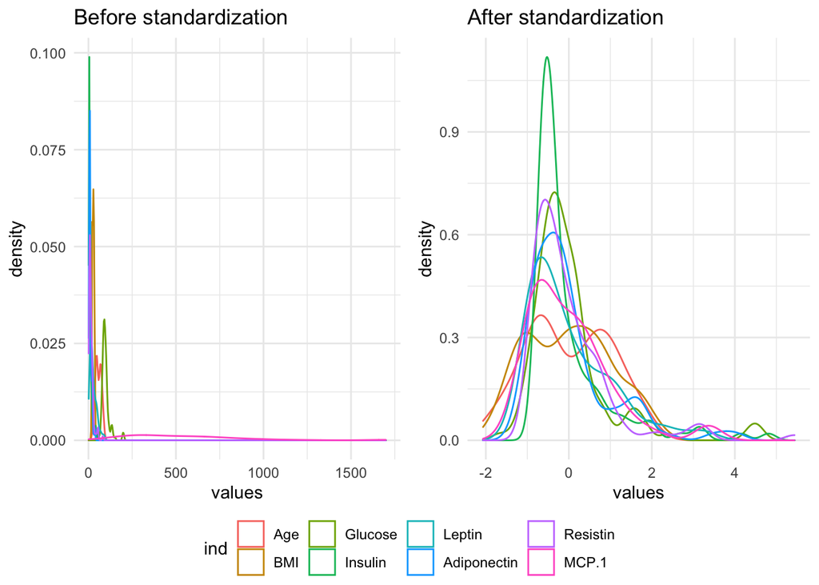

```r
df <- as.data.frame(cancer[c(-5,-10)])
dfs <- stack(df)
plot1 <- ggplot(dfs, aes (x=values)) +
  geom_density(aes(group=ind, colour=ind)) + theme_minimal() +
  theme(legend.position = "none") + ggtitle("Before standardization")

df2 <- as.data.frame(scale(cancer[c(-5,-10)], center = TRUE, scale = TRUE))
dfs2 <- stack(df2)
plot2 <- ggplot(dfs2, aes (x=values)) +
  geom_density(aes(group=ind, colour=ind)) + theme_minimal() +
  theme(legend.position = "none") + ggtitle("After standardization")

ggarrange(plot1, plot2, ncol=2, nrow=1, common.legend = TRUE, legend="bottom")
```

Let’s see *PCA* results:

```r
summary(PCA)
```

```
## Importance of components:
##                           PC1    PC2    PC3    PC4     PC5     PC6     PC7
## Standard deviation     1.5695 1.0960 1.0794 1.0514 0.83515 0.80502 0.65313
## Proportion of Variance 0.3079 0.1502 0.1457 0.1382 0.08718 0.08101 0.05332
## Cumulative Proportion  0.3079 0.4581 0.6037 0.7419 0.82911 0.91012 0.96344
##                            PC8
## Standard deviation     0.54081
## Proportion of Variance 0.03656
## Cumulative Proportion  1.00000
```

We get 8 principal components, since the dataset has 8 predictors: each of these components contains the explanation of a certain proportion of the variance of the dataset. The summary shows that the first principal component explains almost the 31% of the total variation of the dataset, while the first two principal components together explain almost the 46% as the second one overcomes the 15%. It is sufficient to consider the first 5 principal components to overtake the level of 80% of the variance, or the first 6 to exceed the 91%. We can see this with two plots: on the left we plot how the proportion of variance decreases when we pass from a principal component to the following one and on the right we plot how cumulative proportion of variance increases when adding another principal component to the previous ones.

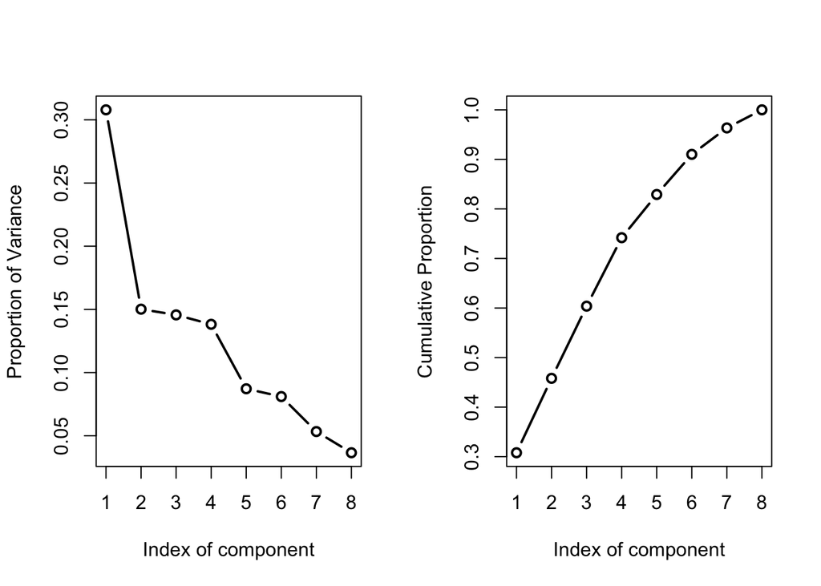

```r
par(mfrow=c(1,2))
plot(summary(PCA)$importance["Proportion of Variance",], type="b", lwd=2, lty=1, xlab = "Index of component", ylab = "Proportion of Variance")
plot(summary(PCA)$importance["Cumulative Proportion",], type="b", lwd=2, lty=1, xlab = "Index of component", ylab = "Cumulative Proportion")
```

```r
par(mfrow=c(1,1))
```

Now we plot a graph that provides the best two-dimensional approximation to the observations in our dataset, since we use as axes the first two principal components. We will also be able to see where the observations are placed with respect to the loading vectors.

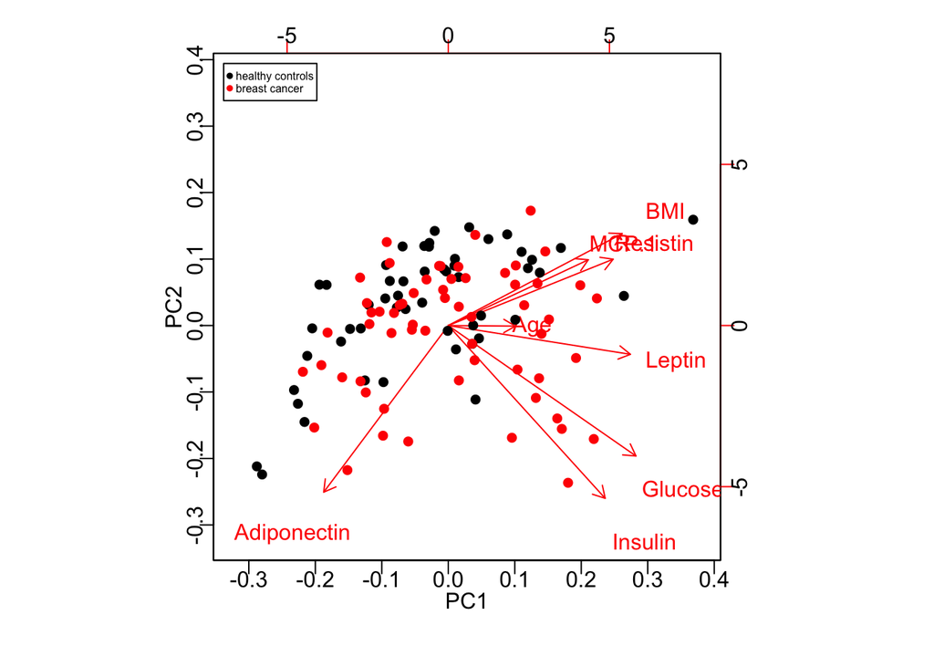

```r
par(mar=c(4,2,2,2), mgp=c(1,0.2,0))
biplot(PCA,choices=c(1,2), xlabs = rep("", nrow(cancer)))
par(mar = c(3,2,1.5,2), mgp = c(2,3.2,0))
points(x=2*PCA$x[,1],y=2*PCA$x[,2],col=cancer$Classification, pch = 16)
legend("topleft", inset=.02,
       c("healthy controls","breast cancer"), pch=c(19,19), col = c(1,2), cex=0.5)
```

The more the features are located close to each other, the more they are related with each other. For example, *BMI*, *MCP-1* and *Resistin* seem to be quite related. It is also possible to observe that patients with high levels of *Insulin* and *Glucose* will probably be classified into the *breast cancer* class.

#### PCA applied to $k$NN

We now perform the same *$k$NN* model as before with just the first 5 principal components which overtake the 80% of the total variance.

```r
PCAdata<-cbind(PCA$x[,1:5],cancer$Classification)
colnames(PCAdata)<-c("pc1","pc2","pc3","pc4","pc5", "Classification")
PCATraindata<-PCAdata[Samples,]
PCATestdata<-PCAdata[-Samples,]

PCAkNNpred<- knn(train = PCATraindata[,-6], test = PCATestdata[,-6], cl=PCATraindata[,6],
                   k=kappa)
PCAkNN_table<-table(PCAkNNpred,PCATestdata[,6], dnn=c("Predicted", "Actual"))
PCAkNN_table
```

```
##          Actual
## Predicted  1  2
##         1 10  4
##         2  4 17
```

```r
PCAkNNaccuracy<-sum(diag(PCAkNN_table))/sum(PCAkNN_table)
PCAkNNaccuracy
```

```
## [1] 0.7714286
```

The accuracy reaches the 77.1% so we get a big improvement in terms of accuracy by reducing the dimesion of the predictors’ space: this shows clearly that *$k$NN* performs better when we do not have too many features. We can notice a big improvement also in the predicitons: now 17 out of 21 patients with breast cancer are correclty classified and 10 out of 14 healthy patients result having healthy controls (remember that 1 stands for *‘healthy controls’* and 2 stands for *‘breast cancer’*).

## Decision Tree

A quite simple method for classification is the *Decision Tree*, where the main idea is to split the space of the features into a number of simple non-overlapping regions and to assign each new observation to the most commonly occuring class (the mode class) of the training observations in its region. The name of this technique comes from the fact that the rules that divide the whole space into many regions can be represented as a tree. A decision tree is characterized by:

- the internal nodes which are the points along the tree where the predictor space is split into a binary partition after a test on a single feature (the first node is called root node);
- the branches which connect two nodes and represent the two possible outcomes of the test on an internal node;
- the leaves or terminal nodes which are the final regions of the partition.

This method has a top-down approach beacuse the algorithm starts from the whole attributes’ space and then it is split with a binary partition represented by two new branches that move away from the root. The algorithm is also considered greedy because in the tree-building process the splits are not picked in order to get the best possible tree in term of accuracy, but each split is the best possible at that particular step of the algorithm. In order to build this classifier we need some criteria to construct the regions: of course we want the classification error to be as small as possible. We define

$\hat{p}_{mk} =\frac{1}{N_m}\sum_{x_i\in R_m}{\mathbb{I}(y_i=k)}$

$k(m)=\arg\max_k \hat{p}_{km}$

respectively as the proportion of class $k$ observations in the $m$-th region of the partition of the whole space and as the most frequent class in the $m$-th region. Then for each region we have the so-called *classification error rate*, defined as $E=1-\hat{p}_{mk(m)}$, that is defined as the fraction of the training observations in the region that do not belong to the most common class of that region. At each step of the tree-building process, the algorithm selects the best split in terms of minimizion of $E$. Anyway this is not sufficiently sensitive for tree-growing, so there are two other indeces that are usually preferred to it.

- Gini index $G=\sum_{k=1}^{K}{\hat{p}_{mk}(1-\hat{p}_{mk})}$ that is a measure of total variance across all the $K$ classes: it becomes smaller as $\hat{p}_{mk}$ gets close to $0$ or $1$.
- Cross entropy or deviance $D=-\sum_{k=1}^{K}{\hat{p}_{mk}\log\hat{p}_{mk}}$ that is numerically similar but alternative to Gini index.

A small value for $G$ or $D$ in a certain region of the partition means that the considered region contains predominantly observations of the same class.

It is quite common that the accuracy of a decision tree is not really high if compared to other classifiers because this model has the problem of overfitting: this classifier adapts too much to the dataset so it is not very performing on the test set that contains different observations. A way to reduce the risk of overfitting is to *prune* the tree: this technique aims to reduce the size of the learning tree without losing in accuracy. The idea is to build an initial tree where each leaf contains a small number of observations (even just one) and then removing the nodes of the tree that do not provide a notable information for classification. Anyway if we fit the decision tree as described, even with pruning, it is quite common to get a model which is worse in terms of accuracy.

Now we fit a decision tree for our classification problem: here we use the *5-folds cross-validation* to tune the parameter which represents the maximum allowed depth for our tree model. The *rpart* function fits a decision tree with recursive partitioning using the Gini index for the splits.

```r
set.seed(2017)
tune <- expand.grid(maxdepth = c(1: 10))
control <- trainControl(method = "cv", number = 5, search = "grid")
treeModel <- train(Classification~.,
                   data = TrainSet,
                   method = "rpart2",
                   metric = "Accuracy",
                   tuneGrid=tune,
                   trControl = control
)
treeModel
```

```
## CART
##
## 81 samples
##  8 predictor
##  2 classes: 'healthy controls', 'breast cancer'
##
## No pre-processing
## Resampling: Cross-Validated (5 fold)
## Summary of sample sizes: 65, 64, 64, 66, 65
## Resampling results across tuning parameters:
##
##   maxdepth  Accuracy   Kappa
##    1        0.5418627  0.09964668
##    2        0.6380882  0.27420465
##    3        0.6365196  0.26407215
##    4        0.6240196  0.23907215
##    5        0.6240196  0.23907215
##    6        0.6240196  0.23907215
##    7        0.6240196  0.23907215
##    8        0.6240196  0.23907215
##    9        0.6240196  0.23907215
##   10        0.6240196  0.23907215
##
## Accuracy was used to select the optimal model using the largest value.
## The final value used for the model was maxdepth = 2.
```

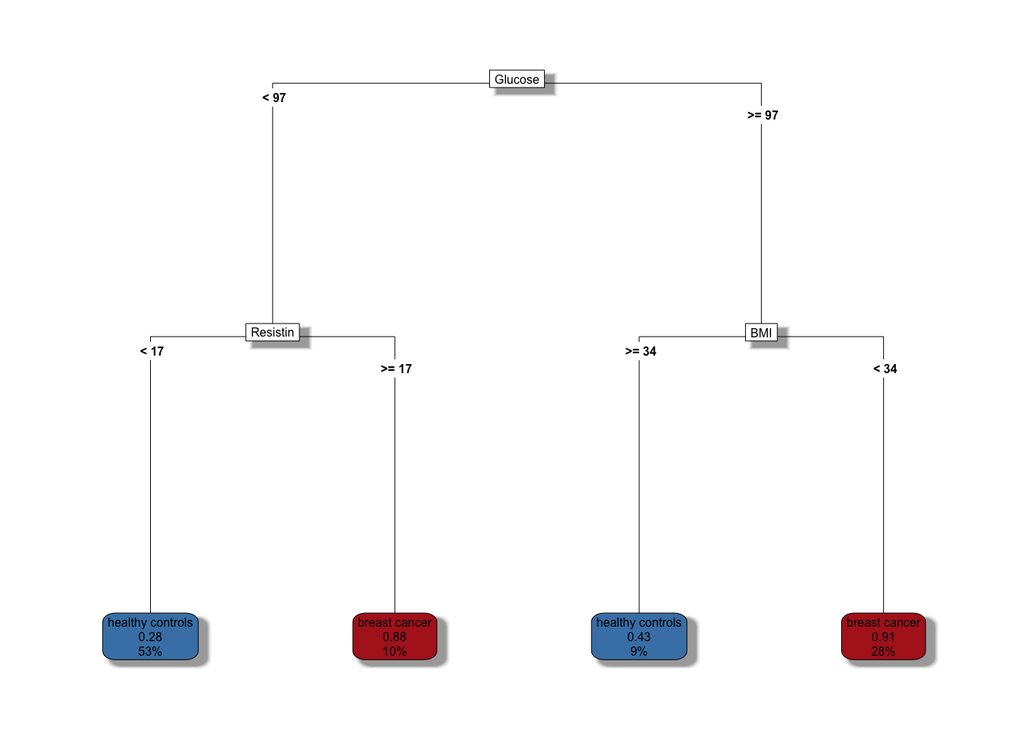

```r
#save the best value of maxdepth
depth<-treeModel$bestTune$maxdepth

DecTree <- rpart(Classification~., data = TrainSet, method = 'class', control = rpart.control(maxdepth = depth))
rpart.plot (DecTree, extra = 106, type=5, cex = 0.5,
            box.palette = c("steelblue","firebrick"), shadow.col = "darkgray")
```

Each leaf of the plotted tree shows:

- the predicted class for an observation with the proper values of the attributes;
- the predicted probability to belong to the *‘breast cancer’* class;
- the percentage of training observations that belong to that leaf.

This draw shows how the decision tree model is very easy to explain even to those who do not know about stastics or machine learning algorithms beacuse it is quite intuitive: this is one of the most valuable advantages of this model along with the absence of need to preprocess the data. It is clear from the plot above that the attributes that have the largest weight in this classifier are *Glucose*, *Resistin* and *BMI*. Now we use the model to predict patients’ health in the test set: in this way we find the accuracy of the decision tree above.

```r
Prediction <- predict(DecTree, TestSet, type = 'class')
Tab <- table(Prediction, TestSet$Classification, dnn=c("Predicted", "Actual"))
Tab
```

```
##                   Actual
## Predicted          healthy controls breast cancer
##   healthy controls                8             5
##   breast cancer                   6            16
```

```r
Accuracy <- sum(diag(Tab))/sum(Tab)
Accuracy
```

```
## [1] 0.6857143
```

The accuracy of this model does not reach the 69%, so it is not as good as logistic regression but it is not worse than *$k$NN*. However there are two main advantages in building decision trees: they are very easy to read and they allow us to build other classifiers which perform better.

## Bagging and Random Forest

One of the most common methods to improve the decision tree model is performing a *random forest*. This approach, along with boosting, uses trees as blocks to build a more powerful classifier which does not overfit the training data. The random forest algorithm applies the technique of *bagging* to tree learners. Bagging method consists in generating $B$ different bootstrapped training datasets from the original one, by repeatedly sampling at random from it (with replacement); then a classifier is built on every dataset and the final classifier is obtained as the average of the classifiers. As we are considering a classification problem we record the class predicted by every single classifier of the model and at the end the final prediction at point $x$ is given by the most common class among the $B$ different predictions at $x$ (this is called the majority vote). This approach guarantees an improvement in terms of accuracy in comparison with a single tree, but clearly it is computationally heavier. The test error for a bagged model is evaluated with the *out-of-bag (OOB) error*. Each tree of the model uses about two-thirds of the total observations of the dataset: we call out-of-bag observations those not used to build the tree. The predicted class of an observation is obtained by taking the majority vote for that observation between the trees in which that instance is OOB. This technique is consider equivalent to the *Leave-One-Out cross-validation* and it estimates the error for the bagged model.

The main idea of random forest is to go beyond bagging in order to decorrelate the trees of the model: each time we have to split the attributes’ space, the model picks randomly a subset of $m$ features and then the division is made considering the selected features only. This process is repeated for any split of any tree of the random forest. A typical choice for the value of $m$ is $m\approx \sqrt{p}$, where $p$ is the number of predictors in the dataset. This technique of using different sets of predictors for different splits decorrelates the trees, so that the final model has a small variance if compared to a single decision tree method.

The *randomForest* function of R requires different parameters to be set: the number of trees (*ntree*), the number $m$ of predictors to be considered at each split (*mtry*), the maximum number of leaves for a single tree (*maxnodes*) and many others. In order to build the best possible random forest model with respect to *ntree*, *mtry* and *maxnodes*, we first fit the model with the default values of these parameters and then we tune them one at a time.

```r
rf_default <- train(Classification~.,
                    data = TrainSet,
                    method = "rf",
                    metric = "Accuracy"
)
print(rf_default)
```

```
## Random Forest
##
## 81 samples
##  8 predictor
##  2 classes: 'healthy controls', 'breast cancer'
##
## No pre-processing
## Resampling: Bootstrapped (25 reps)
## Summary of sample sizes: 81, 81, 81, 81, 81, 81, ...
## Resampling results across tuning parameters:
##
##   mtry  Accuracy   Kappa
##   2     0.6787464  0.3614022
##   5     0.6873919  0.3753270
##   8     0.6809767  0.3622767
##
## Accuracy was used to select the optimal model using the largest value.
## The final value used for the model was mtry = 5.
```

```r
set.seed(2016)
tuneGrid <- expand.grid(mtry = c(1: 8))
trControl <- trainControl(method = "cv", number = 5, search = "grid")
rf_mtry <- train(Classification~.,
                 data = TrainSet,
                 method = "rf",
                 metric = "Accuracy",
                 tuneGrid = tuneGrid,
                 trControl = trControl,
                 importance = TRUE,
                 nodesize = 6,
                 ntree = 300
)

rf_mtry
```

```
## Random Forest
##
## 81 samples
##  8 predictor
##  2 classes: 'healthy controls', 'breast cancer'
##
## No pre-processing
## Resampling: Cross-Validated (5 fold)
## Summary of sample sizes: 64, 64, 65, 65, 66
## Resampling results across tuning parameters:
##
##   mtry  Accuracy   Kappa
##   1     0.6789216  0.3479492
##   2     0.7518137  0.4962411
##   3     0.7556863  0.5013168
##   4     0.7431863  0.4776310
##   5     0.7674510  0.5260426
##   6     0.7549510  0.5044990
##   7     0.7329902  0.4582603
##   8     0.7306863  0.4522739
##
## Accuracy was used to select the optimal model using the largest value.
## The final value used for the model was mtry = 5.
```

```r
#save the best value
best_mtry <- rf_mtry$bestTune$mtry
```

Now we tune the *maxnode* parameter considering a grid of values between 4 and 20 with a difference of 2 between to close values. Moreover here we use the best value for *mtry* we just found.

```r
store_maxnode <- list()
tuneGrid <- expand.grid(.mtry = best_mtry)
for (maxnodes in seq(4,20,by=2)) {
  set.seed(1234)
  rf_maxnode <- train(Classification~.,
                      data = TrainSet,
                      method = "rf",
                      metric = "Accuracy",
                      tuneGrid = tuneGrid,
                      trControl = trControl,
                      importance = TRUE,
                      nodesize = 6,
                      maxnodes = maxnodes,
                      ntree = 300)
  current_iteration <- toString(maxnodes)
  store_maxnode[[current_iteration]] <- rf_maxnode
}

results_mtry <- resamples(store_maxnode)
summary(results_mtry)
```

```
##
## Call:
## summary.resamples(object = results_mtry)
##
## Models: 4, 6, 8, 10, 12, 14, 16, 18, 20
## Number of resamples: 5
##
## Accuracy
##         Min.   1st Qu.    Median      Mean   3rd Qu.      Max. NA's
## 4  0.6000000 0.6250000 0.8125000 0.7486765 0.8235294 0.8823529    0
## 6  0.6250000 0.6666667 0.7647059 0.7392157 0.7647059 0.8750000    0
## 8  0.6666667 0.6875000 0.8235294 0.7987745 0.8750000 0.9411765    0
## 10 0.6250000 0.6666667 0.7647059 0.7509804 0.8235294 0.8750000    0
## 12 0.6250000 0.6666667 0.7647059 0.7627451 0.8750000 0.8823529    0
## 14 0.6250000 0.6666667 0.7647059 0.7627451 0.8750000 0.8823529    0
## 16 0.6250000 0.6666667 0.7647059 0.7627451 0.8750000 0.8823529    0
## 18 0.6250000 0.6666667 0.7647059 0.7627451 0.8750000 0.8823529    0
## 20 0.6250000 0.6666667 0.7647059 0.7627451 0.8750000 0.8823529    0
##
## Kappa
##         Min.   1st Qu.    Median      Mean   3rd Qu.      Max. NA's
## 4  0.1666667 0.2380952 0.6250000 0.4883853 0.6482759 0.7638889    0
## 6  0.2380952 0.3119266 0.5211268 0.4710790 0.5342466 0.7500000    0
## 8  0.3119266 0.3750000 0.6433566 0.5926084 0.7500000 0.8827586    0
## 10 0.2380952 0.3119266 0.5211268 0.4948420 0.6530612 0.7500000    0
## 12 0.2380952 0.3119266 0.5211268 0.5176544 0.7500000 0.7671233    0
## 14 0.2380952 0.3119266 0.5211268 0.5176544 0.7500000 0.7671233    0
## 16 0.2380952 0.3119266 0.5211268 0.5176544 0.7500000 0.7671233    0
## 18 0.2380952 0.3119266 0.5211268 0.5176544 0.7500000 0.7671233    0
## 20 0.2380952 0.3119266 0.5211268 0.5176544 0.7500000 0.7671233    0
```

```r
store_maxtrees <- list()
for (ntree in c(250, 300, 350, 400, 450, 500, 550, 600, 650)) {
  set.seed(5678)
  rf_maxtrees <- train(Classification~.,
                       data = TrainSet,
                       method = "rf",
                       metric = "Accuracy",
                       tuneGrid = tuneGrid,
                       trControl = trControl,
                       importance = TRUE,
                       nodesize = 6,
                       maxnodes = 8,
                       ntree = ntree)
  key <- toString(ntree)
  store_maxtrees[[key]] <- rf_maxtrees
}

results_tree <- resamples(store_maxtrees)
summary(results_tree)
```

```
##
## Call:
## summary.resamples(object = results_tree)
##
## Models: 250, 300, 350, 400, 450, 500, 550, 600, 650
## Number of resamples: 5
##
## Accuracy
##       Min. 1st Qu.    Median      Mean   3rd Qu.  Max. NA's
## 250 0.5625   0.625 0.6875000 0.6911765 0.7058824 0.875    0
## 300 0.6250   0.625 0.6875000 0.7036765 0.7058824 0.875    0
## 350 0.6250   0.625 0.6875000 0.7036765 0.7058824 0.875    0
## 400 0.5625   0.625 0.6470588 0.6794118 0.6875000 0.875    0
## 450 0.5625   0.625 0.6470588 0.6919118 0.7500000 0.875    0
## 500 0.5625   0.625 0.6470588 0.6794118 0.6875000 0.875    0
## 550 0.5625   0.625 0.6470588 0.6794118 0.6875000 0.875    0
## 600 0.5625   0.625 0.6250000 0.6669118 0.6470588 0.875    0
## 650 0.5625   0.625 0.6250000 0.6669118 0.6470588 0.875    0
##
## Kappa
##           Min. 1st Qu.    Median      Mean   3rd Qu.      Max. NA's
## 250 0.09677419    0.25 0.3750000 0.3762430 0.4055944 0.7538462    0
## 300 0.23809524    0.25 0.3750000 0.4045072 0.4055944 0.7538462    0
## 350 0.23809524    0.25 0.3750000 0.4045072 0.4055944 0.7538462    0
## 400 0.09677419    0.25 0.2816901 0.3514621 0.3750000 0.7538462    0
## 450 0.09677419    0.25 0.2816901 0.3764621 0.5000000 0.7538462    0
## 500 0.09677419    0.25 0.2816901 0.3514621 0.3750000 0.7538462    0
## 550 0.09677419    0.25 0.2816901 0.3514621 0.3750000 0.7538462    0
## 600 0.09677419    0.25 0.2500000 0.3264621 0.2816901 0.7538462    0
## 650 0.09677419    0.25 0.2500000 0.3264621 0.2816901 0.7538462    0
```

The narrower interval for accuracy is obtained with both random forests of 300 and 350 trees so for an easier computation we set *ntree*=300. Now, at last, we tune again the *mtry* parameter beacuse is it the most important in affecting the random forest performances. With the new *mtry* value then we build the final random forest model.

```r
tuneGrid <- expand.grid(mtry = c(1: 8))
rf_mtry <- train(Classification~.,
                 data = TrainSet,
                 method = "rf",
                 metric = "Accuracy",
                 tuneGrid = tuneGrid,
                 trControl = trControl,
                 importance = TRUE,
                 nodesize = 6,
                 ntree = 300,
                 maxnodes = 8)
rf_mtry
```

```
## Random Forest
##
## 81 samples
##  8 predictor
##  2 classes: 'healthy controls', 'breast cancer'
##
## No pre-processing
## Resampling: Cross-Validated (5 fold)
## Summary of sample sizes: 64, 66, 65, 65, 64
## Resampling results across tuning parameters:
##
##   mtry  Accuracy   Kappa
##   1     0.6892157  0.3728035
##   2     0.7274510  0.4457862
##   3     0.7016176  0.3983476
##   4     0.7752451  0.5479845
##   5     0.7274510  0.4493693
##   6     0.7383824  0.4750663
##   7     0.7641176  0.5241168
##   8     0.7649510  0.5266627
##
## Accuracy was used to select the optimal model using the largest value.
## The final value used for the model was mtry = 4.
```

```r
#save the new best mtry value
best_mtry <- rf_mtry$bestTune$mtry
tuneGrid <- expand.grid(.mtry = best_mtry)

#final model with the tuned parameters and prediction
set.seed(2016)
RFtot <- randomForest(Classification~. , ntree=300, maxnodes = 8, nodesize = 6, mtry=best_mtry, data = TrainSet)
RFprediction <-predict(RFtot, TestSet)
RFtable <- table(RFprediction, TestSet$Classification, dnn=c("Predicted", "Actual"))
RFtable
```

```
##                   Actual
## Predicted          healthy controls breast cancer
##   healthy controls                7             3
##   breast cancer                   7            18
```

```r
RFaccuracy <- sum(diag(RFtable))/sum(RFtable)
RFaccuracy
```

```
## [1] 0.7142857
```

The accuracy reaches almost the 71.5% so we get a slight improvement compared to the decision tree model. This can be seen by the table above: we improved a bit the classification of patients with breast cancer while there’s not a lot of change in the classification of healthy patients. Even if the improvement is not so big, the results obtained underlines how a single tree does not produce a so good model, but a large number of trees, as in random forest, can improve the accuracy: obviously we lose in terms of computational speed. At the end we plot the importance of each of the features in the classifier we just built.

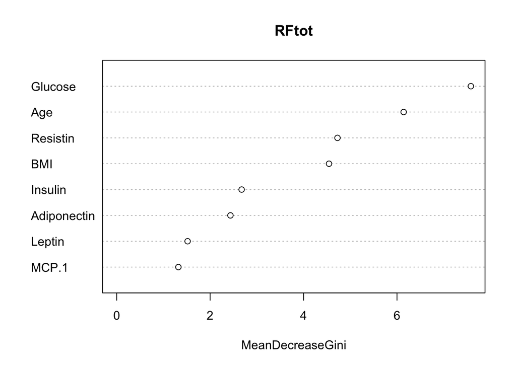

```r
varImpPlot(RFtot)
```

As we already observed before, the variable *Glucose* is the most important one in building our classfier.

## Support Vector Machine

*Support vector machine* (*SVM*) is one of the most recent and performing approaches in classification problems: this method is a more complex version of the *maximal margin vector classifier* and *linear support vector classifier*. The main difference is the fact that the decision boudaries are no more linear as in those two classifiers: in such situations the predictors’ space is enlarged through non linear functions of the features. A typical example is using quadratic, cubic, polynomial transformations: for example it is possible to build a classifier which does not consider only the original $p$ features $x_1,\dots,x_p$ but it uses $2p$ attributes $x_1,x_1^2,\dots,x_p,x_p^2$. So the main idea of the support vector machine is to enlarge the features space in order to build a classifier which is suitable for non linear decision boundaries: the functions that are used to enlarge the space are called *kernels* and they can have very different expressions. It can be demonstrated that the linear support vector classifier can be found by computing inner products only: in the *SVM* kernels measure the similarity of two observations and they replace the inner product. Some kernels (represented with the letter $K$) are:

- linear kernel $K(x_i,x_{i'})=\sum_{j=1}^{p}{x_{ij}x_{i'j}}$, which is the simple inner product and it uses Pearson standard correlation to quantify the similarity of two instances;
- polynomial kernel (of degree $d\in\mathbb{N}$) $K(x_i,x_{i'})=(1+\sum_{j=1}^{p}{x_{ij}x_{i'j}})^d$, which is used with $d>1$ and it builds flexible decision boudaries by fitting a support vector classifier in a higher-dimensional feature space than the original one;
- radial kernel $K(x_i,x_{i'})=\exp (-\gamma\sum_{j=1}^{p}{(x_{ij}-x_{i'j})^2)}$, with $\gamma>0$, whose basic idea is that in classifying $\bar{x}$ we give no weight to those observations that are far from $\bar{x}$: in this sense the radial kernel has very local behaviour.

```r
set.seed(2026)
trControl<- trainControl(method = "repeatedcv", repeats = 5, search = "grid")
svmModel <- train(Classification ~ .,
                  data = TrainSet,
                  method = "svmRadial",
                  metric = "Accuracy",
                  preProc = c("center", "scale"),
                  trControl = trControl
                  )
svmModel
```

```
## Support Vector Machines with Radial Basis Function Kernel
##
## 81 samples
##  8 predictor
##  2 classes: 'healthy controls', 'breast cancer'
##
## Pre-processing: centered (8), scaled (8)
## Resampling: Cross-Validated (10 fold, repeated 5 times)
## Summary of sample sizes: 74, 72, 73, 72, 73, 73, ...
## Resampling results across tuning parameters:
##
##   C     Accuracy   Kappa
##   0.25  0.6277778  0.2293654
##   0.50  0.7134524  0.4170207
##   1.00  0.7100000  0.4118604
##
## Tuning parameter 'sigma' was held constant at a value of 0.1213946
## Accuracy was used to select the optimal model using the largest value.
## The final values used for the model were sigma = 0.1213946 and C = 0.5.
```

```r
C<-svmModel$bestTune$C
sigma<-svmModel$bestTune$sigma
fit_svm <- svm(Classification ~ .,
               data = TrainSet,
               kernel = "radial",
               type = "C-classification",
               cost=C,
               gamma=sigma,
               probability=TRUE #needed for graph representation
               )
fit_svm
```

```
##
## Call:
## svm(formula = Classification ~ ., data = TrainSet, kernel = "radial",
##     type = "C-classification", cost = C, gamma = sigma, probability = TRUE)
##
##
## Parameters:
##    SVM-Type:  C-classification
##  SVM-Kernel:  radial
##        cost:  0.5
##
## Number of Support Vectors:  72
```

```r
predSVM<-predict(fit_svm, TestSet)
svm_table <- table(predSVM, TestSet[,9], dnn=c("Predicted", "Actual"))
svm_table
```

```
##                   Actual
## Predicted          healthy controls breast cancer
##   healthy controls                9             3
##   breast cancer                   5            18
```

```r
svm_acc <- sum(diag(svm_table))/sum(svm_table)
svm_acc
```

```
## [1] 0.7714286
```

### PCA applied to SVM

Now we want to compare the model we just fitted, which is probably the best if we take into account both accuracy and computational time, with an analogous classifier trained using the first 6 principal components we got from PCA. We remind that these 6 components described more than the 90% of variance of the whole dataset.

```r
PCAdata<-cbind(PCA$x[,1:6],cancer$Classification)
colnames(PCAdata)<-c("pc1","pc2","pc3","pc4","pc5", "pc6", "Classification")
PCATraindata<-PCAdata[Samples,]
PCATestdata<-PCAdata[-Samples,]

fit_PCAsvm <- svm(Classification ~ .,
              data = PCATraindata,
              kernel = "radial",
              type = "C-classification",
              #preProc = c("center", "scale"),
              cost=C,
              gamma=sigma
              )
fit_PCAsvm
```

```
##
## Call:
## svm(formula = Classification ~ ., data = PCATraindata, kernel = "radial",
##     type = "C-classification", cost = C, gamma = sigma)
##
##
## Parameters:
##    SVM-Type:  C-classification
##  SVM-Kernel:  radial
##        cost:  0.5
##
## Number of Support Vectors:  71
```

```r
PCAsvm_pred <- predict(fit_PCAsvm, PCATestdata)
PCAsvm_table <- table(PCAsvm_pred, PCATestdata[,7], dnn=c("Predicted", "Actual"))
PCAsvm_table
```

```
##          Actual
## Predicted  1  2
##         1 10  4
##         2  4 17
```

```r
PCAsvm_accuracy <- sum(diag(PCAsvm_table))/sum(PCAsvm_table)
PCAsvm_accuracy
```

```
## [1] 0.7714286
```

The accuracy is as high as before even by using a lower-dimensional space of predictors. In our case it is not so relevant since we have a small dataset in terms of dimensions so *SVM* it is a very good classifier and it is not necessary to apply *PCA*. But if the dataset we want to study has a lot of observation then this technique can reduce computational time without losing too much in accuracy.

# Conclusions

As we already observed, *SVM* is the best model due to both computational speed and accuracy, followed by the *logistic regression*. But to have a more clear situation of the models we built, let’s have a look to ROC curves and AUC. The *Receiving Operator Characteristic* (*ROC*) is an operator that evaluates the goodness of a method using different statistics on the axis while *AUC* stands for Area Under the Curve: higher values of the *AUC* correspond to better models. In our case the statistics used for the *ROC* representation are:

- sensitivity:
  $$\begin{equation} \frac{TP}{TP+FN} \end{equation}$$
- specificity:
  $$\begin{equation} \frac{TN}{FP+TN} \end{equation}$$

Notice that the accuracy we computed at the end of every model is given by
$$\begin{equation} \frac{TP+TN}{TP+FP+TN+FN} \end{equation}$$

Before plotting the *ROC* curves and the repsective *AUC*, we also introduce the *F1 score* that allows us to understand better how the classification worked in each model:

$$\begin{equation}
F1 score = \frac{2}{\frac{1}{S}+\frac{1}{P}}
\end{equation}$$
where
$$\begin{equation}
Precision = P = \frac{TP}{TP+FP}
\end{equation}$$

and S stands for sensitivity.

```r
#logistic regression
metglm = c(confusionMatrix(LOOpred,TestSet$Classification,positive="breast cancer")$byClass[1],
           confusionMatrix(LOOpred,TestSet$Classification,positive="breast cancer")$byClass[2],
           confusionMatrix(LOOpred,TestSet$Classification,positive="breast cancer")$byClass[5],
           confusionMatrix(LOOpred,TestSet$Classification,positive="breast cancer")$byClass[7])
metglm
```

```
## Sensitivity Specificity   Precision          F1
##   0.7142857   0.7857143   0.8333333   0.7692308
```

```r
#kNN
metkNN = c(confusionMatrix(kNNpred,TestSet$Classification,positive="breast cancer")$byClass[1],
           confusionMatrix(kNNpred,TestSet$Classification,positive="breast cancer")$byClass[2],
           confusionMatrix(kNNpred,TestSet$Classification,positive="breast cancer")$byClass[5],
           confusionMatrix(kNNpred,TestSet$Classification,positive="breast cancer")$byClass[7])
metkNN
```

```
## Sensitivity Specificity   Precision          F1
##   0.6666667   0.4285714   0.6363636   0.6511628
```

```r
#decision tree
mettree = c(confusionMatrix(Prediction,TestSet$Classification,positive="breast cancer")$byClass[1],
           confusionMatrix(Prediction,TestSet$Classification,positive="breast cancer")$byClass[2],
           confusionMatrix(Prediction,TestSet$Classification,positive="breast cancer")$byClass[5],
           confusionMatrix(Prediction,TestSet$Classification,positive="breast cancer")$byClass[7])
mettree
```

```
## Sensitivity Specificity   Precision          F1
##   0.7619048   0.5714286   0.7272727   0.7441860
```

```r
#random forest
metrf = c(confusionMatrix(RFprediction,TestSet$Classification,positive="breast cancer")$byClass[1],
          confusionMatrix(RFprediction,TestSet$Classification,positive="breast cancer")$byClass[2],
          confusionMatrix(RFprediction,TestSet$Classification,positive="breast cancer")$byClass[5],
          confusionMatrix(RFprediction,TestSet$Classification,positive="breast cancer")$byClass[7])
metrf
```

```
## Sensitivity Specificity   Precision          F1
##   0.8571429   0.5000000   0.7200000   0.7826087
```

```r
#svm
metsvm = c(confusionMatrix(predSVM,TestSet$Classification,positive="breast cancer")$byClass[1],
          confusionMatrix(predSVM,TestSet$Classification,positive="breast cancer")$byClass[2],
          confusionMatrix(predSVM,TestSet$Classification,positive="breast cancer")$byClass[5],
          confusionMatrix(predSVM,TestSet$Classification,positive="breast cancer")$byClass[7])
metsvm
```

```
## Sensitivity Specificity   Precision          F1
##   0.8571429   0.6428571   0.7826087   0.8181818
```

```r
resp<-TestSet$Classification
#logistic regression
pglm<-predict.train(LOOfit, TestSet, type = 'prob')[,"breast cancer"]
suppressMessages(glmroc<-roc(resp,pglm))
glmroc
```

```
##
## Call:
## roc.default(response = resp, predictor = pglm)
##
## Data: pglm in 14 controls (resp healthy controls) < 21 cases (resp breast cancer).
## Area under the curve: 0.7687
```

```r
#kNN
pkNN<-predict.train(kNNModel, newdata = TestSet, type = 'prob')[,"breast cancer"]
suppressMessages(kNNroc<-roc(resp,pkNN))
kNNroc
```

```
##
## Call:
## roc.default(response = resp, predictor = pkNN)
##
## Data: pkNN in 14 controls (resp healthy controls) < 21 cases (resp breast cancer).
## Area under the curve: 0.7483
```

```r
#decision tree
ptree<-predict.train(treeModel, newdata = TestSet, type = 'prob')[,"breast cancer"]
suppressMessages(treeroc<-roc(resp,ptree))
treeroc
```

```
##
## Call:
## roc.default(response = resp, predictor = ptree)
##
## Data: ptree in 14 controls (resp healthy controls) < 21 cases (resp breast cancer).
## Area under the curve: 0.7279
```

```r
#random forest
pRF<-predict(RFtot, TestSet, type = 'prob')[,"breast cancer"]
suppressMessages(RFroc<-roc(resp,pRF))
RFroc
```

```
##
## Call:
## roc.default(response = resp, predictor = pRF)
##
## Data: pRF in 14 controls (resp healthy controls) < 21 cases (resp breast cancer).
## Area under the curve: 0.7908
```

```r
#svm
predictsvm<-predict(fit_svm, TestSet, probability = TRUE)
psvm<-attr(predictsvm,"probabilities")[,"breast cancer"]
suppressMessages(svmroc<-roc(resp,psvm))
svmroc
```

```
##
## Call:
## roc.default(response = resp, predictor = psvm)
##
## Data: psvm in 14 controls (resp healthy controls) < 21 cases (resp breast cancer).
## Area under the curve: 0.8367
```

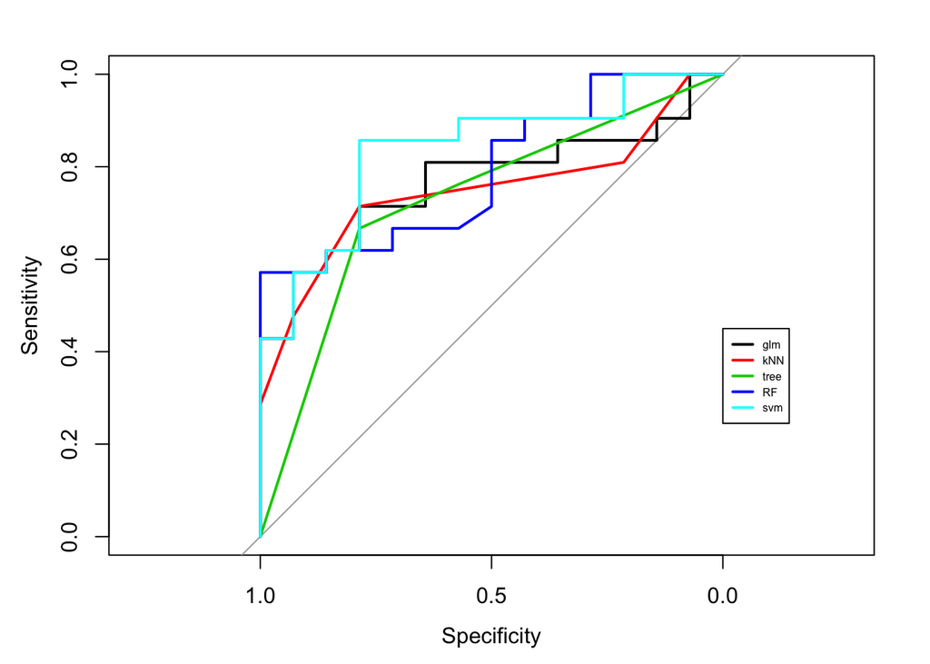

```r
#plots
plot(glmroc)
plot(kNNroc, add=TRUE, col=2)
plot(treeroc,add=TRUE, col=3)
plot(RFroc,add=TRUE, col=4)
plot(svmroc,add=TRUE, col=5)
legend(0,0.45, legend = c("glm","kNN", "tree","RF","svm"), col=c(1,2,3,4,5), lty=c(1,1,1,1,1), lwd=2,cex=0.5)
```

So the AUC are (increasing order):

- decision tree: 0.7279
- $k$NN: 0.7483
- logistic regression: 0.7687
- random forest: 0.7908
- svm: 0.8367